# Behance Analysis - Users

### User Specialization

RQ. What topic is the most popular one and by which gender?

```r
# API call to retrieve pre-defined popular creative fields from behance
cfs<-fromJSON("https://api.behance.net/v2/fields?client_id=ancBdHFrtqhJM18AUzqev2wvgjM0PGnj")
# clean the fields
cfs$fields$abbr_name<-sapply( cfs$fields[2], function(x){
  tolower(gsub(" ", "_", x))
});
systemFields<-as.vector(cfs$fields$abbr_name)
# calculate topic rankings of users' fields
calcTopicRanks<-function(fields){
  userFields<-hash()
  a<-sapply(fields, function(f){
    if (nchar(as.character(f))!=0){
      # process users' fields concatenated by '|'
      splited<-strsplit(as.character(f), "|", fixed = TRUE)
      splited<-unlist(splited)
      for (i in 1:length(splited)){
        field<-tolower(gsub(" ", "_", splited[i]))
        if (has.key(field, userFields)==FALSE){
          userFields[[field]]<-0
        }
        userFields[[field]]<-userFields[[field]]+1
      }
    }
  })
  # sort by the number of users for topics
  userFields<-sort(values(userFields), decreasing=TRUE)
  # return user fields
  userFields
}
# visualize the rankings (up to # rankings)
visualizeRanks<-function(fields, upto){
  ranks<-data.frame(fields=names(fields[1:upto]), counts=fields[1:upto])
  # reorder factors to match colors and bars
  ranks$fill<-factor(ranks$fields, levels = ranks$fields[order(ranks$counts, decreasing=TRUE)])
  ranks$x<-as.character(1:length(ranks$fields))
  ranks$x<-factor(ranks$x, levels = ranks$x[order(ranks$counts, decreasing=TRUE)])
  ggplot(ranks, aes(x=x, y=counts, fill= fill)) +
    geom_bar(stat="identity") +
    guides(fill=guide_legend(ncol=2)) +
    labs(list(x="Fields", y="Users", fill = "Fields"))
}
# calc ranks (warning: slow)
userFields<-calcTopicRanks(users$fields)
maleFields<-calcTopicRanks(subset(users, gender=='male')$fields)
femaleFields<-calcTopicRanks(subset(users, gender=='female')$fields)
```

**Topic rankings (total)**

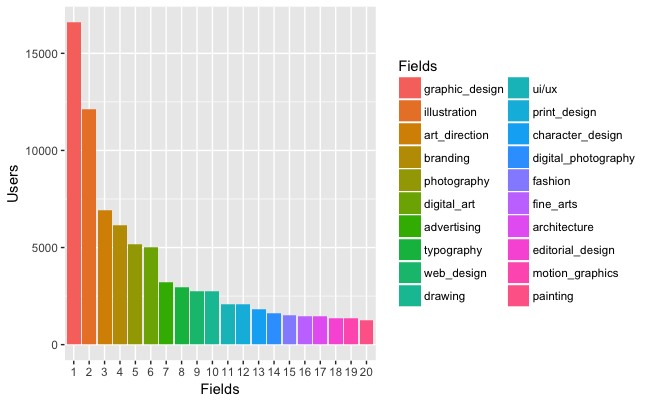

```r
visualizeRanks(userFields, 20)
```

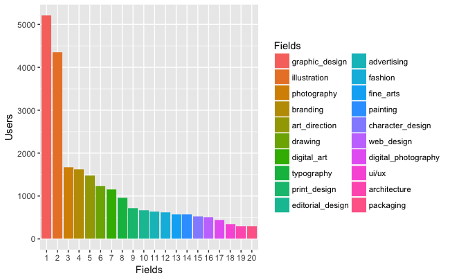

```r
visualizeRanks(femaleFields, 20)
```

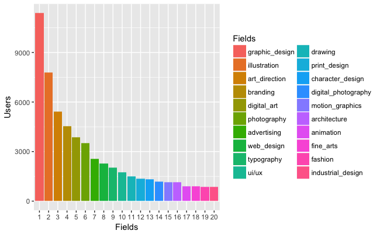

```r
visualizeRanks(maleFields, 20)
```

**Topic diversities (# of topics)**

```r
# field diversities
cbind(c('#of topics (from behance site):', '#of topics (total in our data):', '#of topics (male in our data):', '#of topics (female in our data):'), c(length(systemFields), length(userFields), length(maleFields), length(femaleFields)))
```

```
     [,1]                               [,2]
[1,] "#of topics (from behance site):"  "68"
[2,] "#of topics (total in our data):"  "111"
[3,] "#of topics (male in our data):"   "106"
[4,] "#of topics (female in our data):" "99"
```

**Comparison with system’s popular fields**

system’s popular fields seemed to be picked based on diversity, not actual popularities.

```r
cbind(names(head(userFields, n=12)),cfs$popular$name)
```

```
      [,1]             [,2]
 [1,] "graphic_design" "Graphic Design"
 [2,] "illustration"   "Photography"
 [3,] "art_direction"  "Interaction Design"
 [4,] "branding"       "Art Direction"
 [5,] "photography"    "Illustration"
 [6,] "digital_art"    "Industrial Design"
 [7,] "advertising"    "Motion Graphics"
 [8,] "typography"     "Fashion"
 [9,] "web_design"     "Architecture"
[10,] "drawing"        "Branding"
[11,] "ui/ux"          "Web Design"
[12,] "print_design"   "UI/UX"
```

**Comparison between genders**

web site & ux/ui do not appear in women’s rankings, while they have fashion & editorial_design

```r
cbind(names(head(maleFields, n=12)),names(head(femaleFields, n=12)))
```

```
      [,1]             [,2]
 [1,] "graphic_design" "graphic_design"
 [2,] "illustration"   "illustration"
 [3,] "art_direction"  "photography"
 [4,] "branding"       "branding"
 [5,] "digital_art"    "art_direction"
 [6,] "photography"    "drawing"
 [7,] "advertising"    "digital_art"
 [8,] "web_design"     "typography"
 [9,] "typography"     "print_design"
[10,] "ui/ux"          "editorial_design"
[11,] "drawing"        "advertising"
[12,] "print_design"   "fashion"
```

Add binary category variables (whether a user has a certain field or not)

```r
createCategoryVars<-function(data, field_names){
  for (i in 1:length(field_names)){
    print(paste("creating a variable name of ", paste("has_", field_names[i], sep="")))
    data[, paste("has_", field_names[i],sep="")]<-as.logical(sapply(data$fields, function(f){
      if (nchar(as.character(f))!=0){
        fields<-tolower(gsub(" ", "_", as.character(f)))
        grepl(field_names[i], fields)
      }else{
        FALSE
      }
    }))
  }
  data
}
allgender<-createCategoryVars(allgender, names(userFields[1:15]))
```

```
[1] "creating a variable name of  has_graphic_design"
[1] "creating a variable name of  has_illustration"
[1] "creating a variable name of  has_art_direction"
[1] "creating a variable name of  has_branding"
[1] "creating a variable name of  has_photography"
[1] "creating a variable name of  has_digital_art"
[1] "creating a variable name of  has_advertising"
[1] "creating a variable name of  has_typography"
[1] "creating a variable name of  has_web_design"
[1] "creating a variable name of  has_drawing"
[1] "creating a variable name of  has_ui/ux"
[1] "creating a variable name of  has_print_design"
[1] "creating a variable name of  has_character_design"
[1] "creating a variable name of  has_digital_photography"
[1] "creating a variable name of  has_fashion"
```

```r
count(allgender$has_graphic_design) #sanity check
```

| x | freq |
| --- | --- |
| FALSE | 21198 |
| TRUE | 16579 |

Add binary category variables (whether a user is from a certain country or not)

```r
# add binary country variables
createCountryVars<-function(data, country_names){
  for (i in 1:length(country_names)){
    print(paste("creating a variable name of ", paste("from_", country_names[i], sep="")))
    n<-tolower(gsub(" ", "_", as.character(country_names[i])))
    data[, paste("from_",n, sep="")]<-data$country==country_names[i]
  }
  data
}
allgender<-createCountryVars(allgender, as.character(factor(allGenderP[1:10, ]$country)))
```

```
[1] "creating a variable name of  from_United States"
[1] "creating a variable name of  from_Brazil"
[1] "creating a variable name of  from_United Kingdom"
[1] "creating a variable name of  from_Russian Federation"
[1] "creating a variable name of  from_Italy"
[1] "creating a variable name of  from_India"
[1] "creating a variable name of  from_Spain"
[1] "creating a variable name of  from_Egypt"
[1] "creating a variable name of  from_France"
[1] "creating a variable name of  from_Germany"
```

```r
count(allgender$from_united_states) #sanity check
```

| x | freq |
| --- | --- |
| FALSE | 32347 |
| TRUE | 5430 |

Fix gender factor level (remove unknown fator)

```r
# allgender$gender<-factor(allgender$gender)
```

**The distribution of project appreciations and followers by gender (log-transformed)**

```r
with(allgender, tapply(project_appreciations, gender, describe))
```

```
$female
  vars     n    mean     sd median trimmed    mad min    max  range  skew kurtosis    se
1    1 11124 1509.71 5743.7     99  393.42 146.78   0 169578 169578 11.19   189.66 54.46

$male
  vars     n    mean     sd median trimmed    mad min    max  range  skew kurtosis    se
1    1 26653 2877.72 9869.5    196  917.79 290.59   0 391007 391007 11.65   249.31 60.45
```

```r
x<-log(subset(allgender, gender=='male')$project_appreciations+1)
y<-log(subset(allgender, gender=='female')$project_appreciations+1)
ks.test(x,y)
```

```
p-value will be approximate in the presence of ties
```

```
    Two-sample Kolmogorov-Smirnov test

data:  x and y
D = 0.11054, p-value < 2.2e-16
alternative hypothesis: two-sided
```

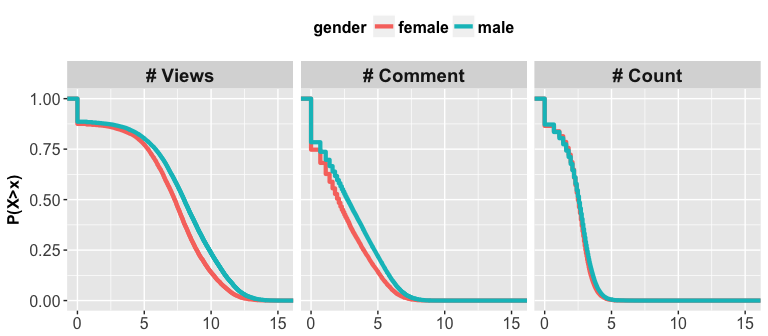

```r
combined<-rbind(cbind(allgender$project_views, allgender$gender, 1),
                cbind(allgender$project_comments, allgender$gender, 2),
                cbind(allgender$project_counts, allgender$gender, 3))
combined<-as.data.frame(combined)
colnames(combined)<-c('value', 'gender', 'group')
combined$gender<-factor(combined$gender, labels=c('female', 'male'))
combined$group<-factor(combined$group, labels=c('# Views', '# Comment', '# Count'))
ggplot(combined, aes(x=log(value+1), y=1 -..y.., colour=gender))+
  stat_ecdf(size=1.5) +
  facet_grid(. ~ group)+
  ylab('P(X>x)') +
  theme(legend.position='top', axis.title.x = element_blank(),
        axis.text.x = element_text(size=12),
        axis.text.y = element_text(size=12),
        strip.text.x = element_text(size=14, face='bold'),
        axis.title.y = element_text(size=12, face='bold'),
        legend.title = element_text(size=12, face='bold'),
        legend.text = element_text(size=12, face='bold'))
```

```r
ggsave('ccdf_1.pdf', width=8, height=3.5) # for publication
```

```r
with(allgender, tapply(followers, gender, describe))
```

```
$female
  vars     n   mean      sd median trimmed  mad min    max  range  skew kurtosis    se
1    1 11124 769.75 4997.93     48  165.66 68.2   0 241009 241009 26.68   982.97 47.39

$male
  vars     n mean     sd median trimmed    mad min    max  range  skew kurtosis    se
1    1 26653 1516 7286.1    114  392.79 164.57   0 332289 332289 18.05   505.16 44.63
```

```r
x<-log(subset(allgender, gender=='male')$followers+1)
y<-log(subset(allgender, gender=='female')$followers+1)
ks.test(x,y)
```

```
p-value will be approximate in the presence of ties
```

```
    Two-sample Kolmogorov-Smirnov test

data:  x and y
D = 0.13965, p-value < 2.2e-16
alternative hypothesis: two-sided
```

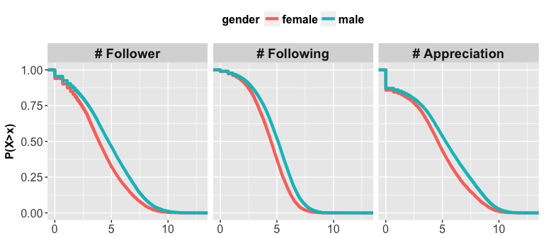

```r
combined<-rbind(cbind(allgender$followers, allgender$gender, 1),
                cbind(allgender$following, allgender$gender, 2),
                cbind(allgender$project_appreciations, allgender$gender, 3))
combined<-as.data.frame(combined)
colnames(combined)<-c('value', 'gender', 'group')
combined$gender<-factor(combined$gender, labels=c('female', 'male'))
combined$group<-factor(combined$group, labels=c('# Follower', '# Following', '# Appreciation'))
ggplot(combined, aes(x=log(value+1), y=1 -..y.., colour=gender))+
  stat_ecdf(size=1.5) +
  facet_grid(. ~ group)+
  ylab('P(X>x)') +
  theme(legend.position='top', axis.title.x = element_blank(),
        axis.text.x = element_text(size=12),
        axis.text.y = element_text(size=12),
        strip.text.x = element_text(size=14, face='bold'),
        axis.title.y = element_text(size=12, face='bold'),
        legend.title = element_text(size=12, face='bold'),
        legend.text = element_text(size=12, face='bold'))
```

```r
ggsave('ccdf_2.pdf', width=8, height=3.5) # for publication
```

**Project appreciation & follower counts within topics**

while graphic_design is the most popular, digital photography seems to have more followers and project appreciations

```r
allPhoto<-subset(allgender, allgender$has_digital_photography==1)
allGraphic<-subset(allgender, allgender$has_graphic_design==1)
describe(allGraphic$project_appreciations)
```

```
  vars     n    mean      sd median trimmed    mad min    max  range  skew kurtosis    se
1    1 16579 2274.66 8964.53    182  640.53 250.56   0 391007 391007 14.92   390.93 69.62
```

```r
describe(allPhoto$project_appreciations)
```

```
  vars    n    mean       sd median trimmed    mad min    max  range skew kurtosis     se
1    1 1628 3311.07 10146.08  319.5 1149.13 454.42   0 139268 139268 7.01     64.4 251.46
```

```r
describe(allGraphic$followers)
```

```
  vars     n    mean      sd median trimmed    mad min    max  range skew kurtosis    se
1    1 16579 1071.57 6356.13     98   267.7 131.95   0 332289 332289 25.5   960.19 49.36
```

```r
describe(allPhoto$followers)
```

```
  vars    n    mean      sd median trimmed    mad min    max  range  skew kurtosis     se
1    1 1628 1719.79 8013.67    133  419.67 182.36   0 190650 190650 13.72   256.64 198.61
```

**Project appreciation & follower counts within countries**

```r
allUS<-subset(allgender, allgender$from_united_states==1)
allBrazil<-subset(allgender, allgender$from_brazil==1)
allItaly<-subset(allgender, allgender$from_italy==1)
describe(allUS$project_appreciations)
```

```
  vars    n    mean      sd median trimmed    mad min    max  range skew kurtosis    se
1    1 5430 2438.93 8783.75     91  642.15 134.92   0 173134 173134 9.07   116.48 119.2
```

```r
describe(allBrazil$project_appreciations)
```

```
  vars    n    mean      sd median trimmed    mad min    max  range  skew kurtosis     se
1    1 3210 1258.36 6192.14    112  313.21 163.09   0 195355 195355 17.09    409.3 109.29
```

```r
describe(allItaly$project_appreciations)
```

```
  vars    n    mean      sd median trimmed    mad min   max range skew kurtosis     se
1    1 1445 2534.05 6501.14    310 1025.46 453.68   0 97630 97630 6.27    59.78 171.02
```

```r
describe(allUS$followers)
```

```
  vars    n    mean     sd median trimmed   mad min    max  range skew kurtosis     se
1    1 5430 1650.79 8139.2     50  302.36 72.65   0 233412 233412 14.9    316.5 110.45
```

```r
describe(allBrazil$followers)
```

```
  vars    n   mean      sd median trimmed   mad min    max  range  skew kurtosis    se
1    1 3210 525.53 2854.84     66  154.99 90.44   0 121288 121288 26.96  1029.62 50.39
```

```r
describe(allItaly$followers)
```

```
  vars    n    mean      sd median trimmed    mad min   max range  skew kurtosis     se
1    1 1445 1149.35 4086.65    136  403.98 194.22   0 81211 81211 11.01   165.74 107.51
```

### Prediction model #1 : negative binomial regression

RQ. What structures connections? DV. # of followers IV. all other attributes *Potential alternative: zero-inflated model, but zero values seem legitimate in my case, not generated by other processes

```r
# remove unused attributes (e.g., user id, user names etc)
colnames(allgender)
```

```
 [1] "user_id"                 "fields"                  "followers"               "following"               "username"
 [6] "gender"                  "country"                 "comments"                "project_counts"          "project_views"
[11] "project_appreciations"   "project_comments"        "created_on"              "has_graphic_design"      "has_illustration"
[16] "has_art_direction"       "has_branding"            "has_photography"         "has_digital_art"         "has_advertising"
[21] "has_typography"          "has_web_design"          "has_drawing"             "has_ui/ux"               "has_print_design"
[26] "has_character_design"    "has_digital_photography" "has_fashion"             "from_united_states"      "from_brazil"
[31] "from_united_kingdom"     "from_russian_federation" "from_italy"              "from_india"              "from_spain"
[36] "from_egypt"              "from_france"             "from_germany"
```

```r
regdata<-allgender[, c(3:4,6,9:12, 14:38)]
names(regdata)
```

```
 [1] "followers"               "following"               "gender"                  "project_counts"          "project_views"
 [6] "project_appreciations"   "project_comments"        "has_graphic_design"      "has_illustration"        "has_art_direction"
[11] "has_branding"            "has_photography"         "has_digital_art"         "has_advertising"         "has_typography"
[16] "has_web_design"          "has_drawing"             "has_ui/ux"               "has_print_design"        "has_character_design"
[21] "has_digital_photography" "has_fashion"             "from_united_states"      "from_brazil"             "from_united_kingdom"
[26] "from_russian_federation" "from_italy"              "from_india"              "from_spain"              "from_egypt"
[31] "from_france"             "from_germany"
```

**Fit a regression on all predictors**

```r
fitnb <- glm.nb(followers ~ ., data = regdata, maxit = 100, trace=TRUE)
```

[output not shown]

```r
summary(fitnb)
```

```
Call:
glm.nb(formula = followers ~ ., data = regdata, maxit = 100,
    trace = TRUE, init.theta = 0.4387307147, link = log)

Deviance Residuals:
    Min       1Q   Median       3Q      Max
-8.8410  -1.1497  -0.5528   0.0916  15.7639

Coefficients:
                              Estimate Std. Error z value Pr(>|z|)
(Intercept)                  4.216e+00  2.165e-02 194.724  < 2e-16 ***
following                    2.507e-04  3.722e-06  67.345  < 2e-16 ***
gendermale                   3.322e-01  1.753e-02  18.954  < 2e-16 ***
project_counts               1.241e-02  2.195e-04  56.551  < 2e-16 ***
project_views                4.196e-06  1.424e-07  29.464  < 2e-16 ***
project_appreciations        1.468e-04  2.318e-06  63.327  < 2e-16 ***
project_comments             1.347e-03  2.366e-05  56.952  < 2e-16 ***
has_graphic_designTRUE      -1.845e-01  1.775e-02 -10.397  < 2e-16 ***
has_illustrationTRUE         1.893e-01  1.919e-02   9.865  < 2e-16 ***
has_art_directionTRUE        3.244e-01  2.111e-02  15.371  < 2e-16 ***
has_brandingTRUE             1.780e-01  2.293e-02   7.764 8.24e-15 ***
has_photographyTRUE          3.856e-02  2.750e-02   1.402   0.1608
has_digital_artTRUE          2.545e-01  2.411e-02  10.557  < 2e-16 ***
has_advertisingTRUE          1.503e-01  2.895e-02   5.193 2.07e-07 ***
has_typographyTRUE           4.578e-01  3.011e-02  15.202  < 2e-16 ***
has_web_designTRUE           2.560e-01  3.479e-02   7.357 1.88e-13 ***
has_drawingTRUE              2.092e-01  3.222e-02   6.493 8.39e-11 ***
`has_ui/ux`TRUE              3.459e-01  3.983e-02   8.685  < 2e-16 ***
has_print_designTRUE         2.114e-01  3.516e-02   6.011 1.84e-09 ***
has_character_designTRUE     3.824e-01  3.819e-02  10.013  < 2e-16 ***
has_digital_photographyTRUE  9.218e-02  4.520e-02   2.039   0.0414 *
has_fashionTRUE              5.610e-01  4.088e-02  13.724  < 2e-16 ***
from_united_statesTRUE       4.224e-01  2.349e-02  17.983  < 2e-16 ***
from_brazilTRUE             -2.862e-01  2.936e-02  -9.750  < 2e-16 ***
from_united_kingdomTRUE      1.706e-01  3.543e-02   4.814 1.48e-06 ***
from_russian_federationTRUE  2.720e-01  3.941e-02   6.900 5.20e-12 ***
from_italyTRUE               2.093e-01  4.140e-02   5.056 4.28e-07 ***
from_indiaTRUE              -6.748e-01  4.324e-02 -15.606  < 2e-16 ***
from_spainTRUE               1.785e-01  4.396e-02   4.061 4.88e-05 ***
from_egyptTRUE              -1.153e-01  4.578e-02  -2.517   0.0118 *
from_franceTRUE              3.556e-01  4.646e-02   7.654 1.95e-14 ***
from_germanyTRUE             5.255e-01  4.876e-02  10.778  < 2e-16 ***
---
Signif. codes:  0 ‘***’ 0.001 ‘**’ 0.01 ‘*’ 0.05 ‘.’ 0.1 ‘ ’ 1

(Dispersion parameter for Negative Binomial(0.4387) family taken to be 1)

    Null deviance: 92019  on 37776  degrees of freedom
Residual deviance: 47528  on 37745  degrees of freedom
AIC: 494171

Number of Fisher Scoring iterations: 1

              Theta:  0.43873
          Std. Err.:  0.00274

 2 x log-likelihood:  -494105.45800
```

```r
1-pchisq(fitnb$null.deviance - fitnb$deviance, df=(fitnb$df.null - fitnb$df.residual))
```

```
[1] 0
```

**Relative importance of predictors**

```r
rel_beta_std[order(abs(rel_beta_std),decreasing = TRUE)]
```

[output not shown]

```
      project_appreciations            project_comments                   following               project_views              project_counts
                0.268170834                 0.150336783                 0.109661339                 0.108336834                 0.095825638
                 gendermale      from_united_statesTRUE       has_art_directionTRUE              from_indiaTRUE          has_typographyTRUE
                0.031157144                 0.030494465                 0.025809369                -0.025647889                 0.025379554
            has_fashionTRUE      has_graphic_designTRUE        has_illustrationTRUE         has_digital_artTRUE            from_germanyTRUE
                0.022971666                -0.018843869                 0.018196432                 0.017796980                 0.017563480
   has_character_designTRUE             from_brazilTRUE             `has_ui/ux`TRUE          has_web_designTRUE            has_brandingTRUE
                0.016921361                -0.016423992                 0.016252549                 0.013731781                 0.013533237
            from_franceTRUE from_russian_federationTRUE             has_drawingTRUE        has_print_designTRUE         has_advertisingTRUE
                0.012471232                 0.011331843                 0.011145791                 0.009881118                 0.008616031
             from_italyTRUE     from_united_kingdomTRUE              from_spainTRUE              from_egyptTRUE has_digital_photographyTRUE
                0.008262562                 0.007923268                 0.006629877                -0.004122509                 0.003852243
        has_photographyTRUE
                0.002784848
```

** Can I improve the model by removing less important variables**

```r
# fit<-update(fitnb, .~. -has_fashionTRUE-has_illustrationTRUE-from_egypt-has_photography
#                -has_graphic_design-frombrazil-from_india)
# anova(fitnb, fit)
```

```r
# summary(fit)
# AIC(fit) # need more experiments to find the final best model.
# AIC(fitnb)
# variable selection (error occurred)
# fitnb_back <- stepAIC(fitnb, trace=FALSE)
# summary(fitnb_back)
```

### Prediction model #2 : negative binomial regression

Q. What structures connections? DV. # of project appreciations IV. all other attributes

**Fit a regression on all predictors**

```r
fitnb_pa <- glm.nb(project_appreciations ~ ., data = regdata, maxit = 100, trace=TRUE)
```

[output not shown]

```r
summary(fitnb_pa)
```

```
Call:
glm.nb(formula = project_appreciations ~ ., data = regdata, maxit = 100,
    trace = TRUE, init.theta = 0.3509557755, link = log)

Deviance Residuals:
    Min       1Q   Median       3Q      Max
-8.9135  -1.1413  -0.5278   0.1436   6.4254

Coefficients:
                              Estimate Std. Error z value Pr(>|z|)
(Intercept)                  4.473e+00  2.419e-02 184.906  < 2e-16 ***
followers                    2.474e-05  1.670e-06  14.818  < 2e-16 ***
following                    8.329e-05  4.166e-06  19.994  < 2e-16 ***
gendermale                   2.493e-01  1.958e-02  12.731  < 2e-16 ***
project_counts               1.812e-02  2.454e-04  73.855  < 2e-16 ***
project_views                1.030e-05  1.072e-07  96.052  < 2e-16 ***
project_comments             2.609e-03  2.347e-05 111.162  < 2e-16 ***
has_graphic_designTRUE       6.994e-02  1.983e-02   3.527 0.000420 ***
has_illustrationTRUE         4.515e-01  2.143e-02  21.071  < 2e-16 ***
has_art_directionTRUE        5.383e-01  2.359e-02  22.822  < 2e-16 ***
has_brandingTRUE             3.973e-01  2.562e-02  15.508  < 2e-16 ***
has_photographyTRUE          2.143e-01  3.072e-02   6.974 3.08e-12 ***
has_digital_artTRUE          4.770e-01  2.693e-02  17.709  < 2e-16 ***
has_advertisingTRUE          2.479e-01  3.235e-02   7.662 1.83e-14 ***
has_typographyTRUE           6.416e-01  3.365e-02  19.068  < 2e-16 ***
has_web_designTRUE           1.324e-01  3.888e-02   3.407 0.000658 ***
has_drawingTRUE              4.688e-01  3.601e-02  13.021  < 2e-16 ***
`has_ui/ux`TRUE              4.671e-01  4.451e-02  10.494  < 2e-16 ***
has_print_designTRUE         3.422e-01  3.929e-02   8.709  < 2e-16 ***
has_character_designTRUE     5.757e-01  4.263e-02  13.503  < 2e-16 ***
has_digital_photographyTRUE  3.504e-01  5.050e-02   6.939 3.95e-12 ***
has_fashionTRUE              3.347e-01  4.570e-02   7.325 2.40e-13 ***
from_united_statesTRUE      -1.034e-01  2.625e-02  -3.939 8.17e-05 ***
from_brazilTRUE             -2.540e-01  3.279e-02  -7.748 9.37e-15 ***
from_united_kingdomTRUE      1.139e-01  3.960e-02   2.876 0.004030 **
from_russian_federationTRUE  5.663e-01  4.403e-02  12.862  < 2e-16 ***
from_italyTRUE               1.928e-01  4.626e-02   4.168 3.07e-05 ***
from_indiaTRUE              -6.425e-01  4.828e-02 -13.308  < 2e-16 ***
from_spainTRUE               1.844e-01  4.912e-02   3.754 0.000174 ***
from_egyptTRUE              -5.615e-01  5.116e-02 -10.975  < 2e-16 ***
from_franceTRUE              3.148e-01  5.194e-02   6.062 1.35e-09 ***
from_germanyTRUE             4.798e-01  5.451e-02   8.802  < 2e-16 ***
---
Signif. codes:  0 ‘***’ 0.001 ‘**’ 0.01 ‘*’ 0.05 ‘.’ 0.1 ‘ ’ 1

(Dispersion parameter for Negative Binomial(0.351) family taken to be 1)

    Null deviance: 84527  on 37776  degrees of freedom
Residual deviance: 47261  on 37745  degrees of freedom
AIC: 525535

Number of Fisher Scoring iterations: 1

              Theta:  0.35096
          Std. Err.:  0.00228

 2 x log-likelihood:  -525468.91700
```

```r
# pchisq(fitnb_pa$deviance, df=fitnb_pa$df.residual, lower.tail=FALSE)
1-pchisq(fitnb_pa$null.deviance - fitnb_pa$deviance, df=(fitnb_pa$df.null - fitnb_pa$df.residual), lower.tail = )
```

```
[1] 0
```

**Relative importance of predictors**

```r
beta_std <- lm.beta(fitnb_pa)
```

```
Calling var(x) on a factor x is deprecated and will become an error.
  Use something like 'all(duplicated(x)[-1L])' to test for a constant vector.
```

```r
rel_beta_std<-beta_std/sum(beta_std)
rel_beta_std[order(abs(rel_beta_std),decreasing = TRUE)]
```

```
           project_comments               project_views              project_counts        has_illustrationTRUE       has_art_directionTRUE
                0.255171759                 0.233082459                 0.122670727                 0.038045404                 0.037536246
                  following          has_typographyTRUE                   followers         has_digital_artTRUE            has_brandingTRUE
                0.031940655                 0.031182106                 0.029917968                 0.029237140                 0.026480983
   has_character_designTRUE             has_drawingTRUE              from_indiaTRUE from_russian_federationTRUE                  gendermale
                0.022332988                 0.021892575                -0.021408148                 0.020684056                 0.020495504
            `has_ui/ux`TRUE              from_egyptTRUE            from_germanyTRUE        has_print_designTRUE         has_photographyTRUE
                0.019239872                -0.017608114                 0.014057321                 0.014023232                 0.013563597
has_digital_photographyTRUE             from_brazilTRUE         has_advertisingTRUE             has_fashionTRUE             from_franceTRUE
                0.012838108                -0.012779203                 0.012453589                 0.012014567                 0.009679013
             from_italyTRUE      from_united_statesTRUE      has_graphic_designTRUE          has_web_designTRUE              from_spainTRUE
                0.006672352                -0.006545769                 0.006261772                 0.006227878                 0.006002552
    from_united_kingdomTRUE
                0.004636810
```

**What if I remove non-significant metrics?**

```r
# fit_pa<-update(fitnb_pa, .~. -from_united_states
#             -from_brazil-from_india-from_egypt-from_united_kingdom-collection_followers)
# anova(fitnb_pa, fit_pa)
```

```r
# summary(fit_pa)
# AIC(fit_pa)
# AIC(fitnb_pa)
```

```r
# variable selection
# : commented because it's too slow
# : results ::  only collection_followers is removed from the full model

# fitnb_pa_back <- stepAIC(fitnb_pa, trace = FALSE)
# summary(fitnb_pa_back)
# modvar <- names(coef(fitnb_pa_back))
# modvar
# fullvar <- names(coef(fitnb_pa))
# fullvar
# excluded <- !fullvar %in% modvar   ## compare strings
# fullvar[excluded]
```